# nba_last30_Rseason_EDA

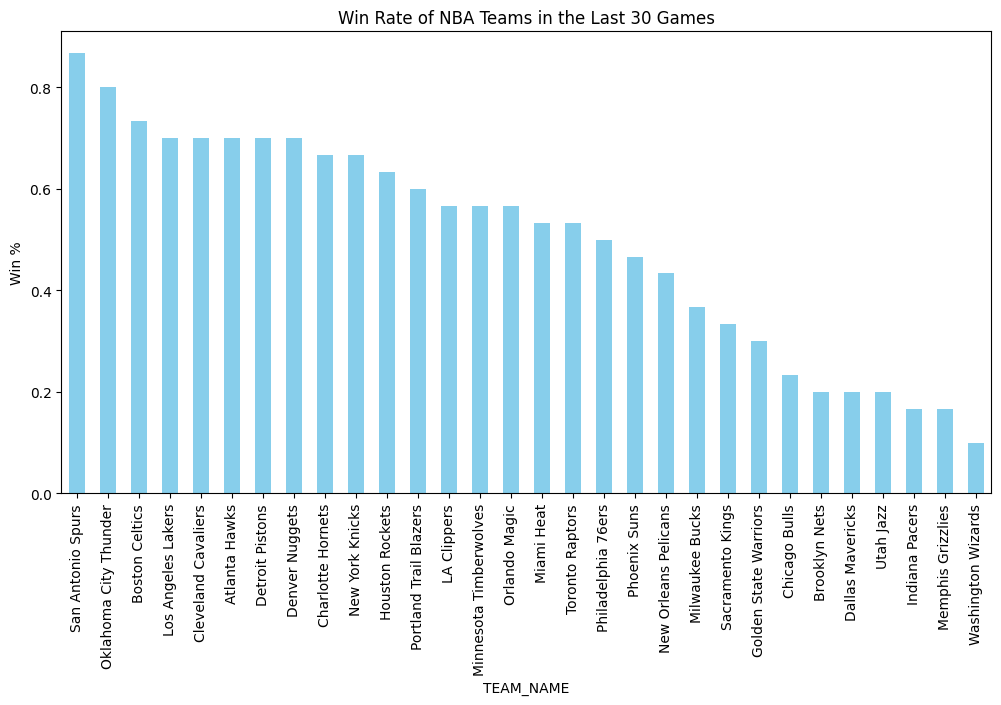

```python
import pandas as pd
import matplotlib.pyplot as plt

# Load the CSV file into a DataFrame
nba_last_30_games = pd.read_csv('nba_last_30_games.csv')

# Convert WL to numeric values (1 for win, 0 for loss)
nba_last_30_games['is_win'] = nba_last_30_games['WL'].apply(lambda x: 1 if x == 'W' else 0)

# Calculate win rate per team
win_rate = nba_last_30_games.groupby('TEAM_NAME')['is_win'].mean().sort_values(ascending=False)

# Plotting the win rates
win_rate.plot(kind='bar', figsize=(12, 6), color='skyblue')
plt.title('Win Rate of NBA Teams in the Last 30 Games')
plt.ylabel('Win %')
plt.show()
```

We can see that from the last 30 games of the 2025-26 NBA regular season that the top three teams in terms of W-L record were the San Antonio Spurs, The Oklahoma City Thunder, and the Boston Celtics; all top teams that one would expect to be there. The bottom three teams in terms of W-L record were the Indiana Pacers, Memphis Grizzlies, and Washington Wizards. Now we'll take a look at other metrics, such as points per game, point differentials, and more to see if we see similar trends.

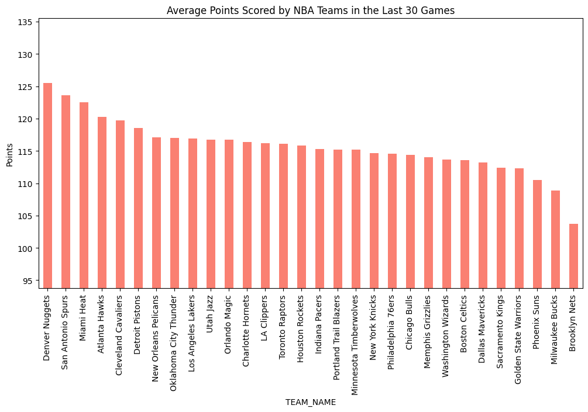

```python
# Average points scored per team
average_points = nba_last_30_games.groupby('TEAM_NAME')['PTS'].mean().sort_values(ascending=False)

# Plotting the average points scored]
average_points.plot(kind='bar', figsize=(12, 6), color='salmon')
plt.title('Average Points Scored by NBA Teams in the Last 30 Games')
plt.ylabel('Points')
plt.ylim(average_points.min() - 10, average_points.max() + 10)
plt.show()
```

As we can see from the plot, only one team among the top and bottom three in terms of W-L record stayed in that group, being the San Anontio Spurs who placed second in scoring among the league, the others in the top two being the Denver Nuggets in first and the Miami Heat in third. The Miami Heat are especially interesting in this plot as they were third in scoring yet only managed to place 16th in the league when it actually came to W-L record. On the flip side of that, you have teams like the Boston Celtics who despite placing third in the league in terms of W-L record, placed a whopping 24th when it came to points per game. Could this be the result of a lack luster defense and elite guarding for the Heat and Celtics respectively? Bad Luck? Next we can look at average point differential to see how those teams ended up where they did.

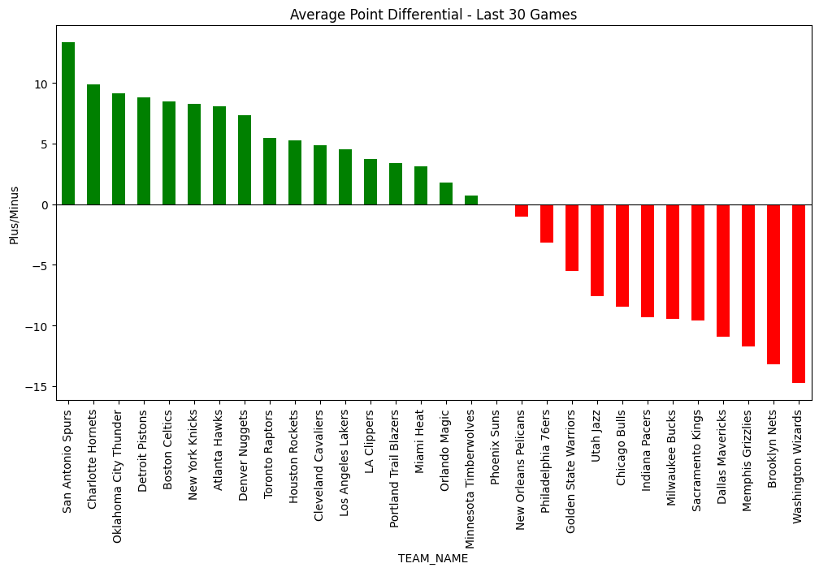

```python
# Average plus/minus per game
net_rating = nba_last_30_games.groupby('TEAM_NAME')['PLUS_MINUS'].mean().sort_values(ascending=False)

# Use colors to distinguish positive vs negative differential
colors = ['green' if x > 0 else 'red' for x in net_rating]

net_rating.plot(kind='bar', figsize=(12, 6), color=colors)
plt.title('Average Point Differential - Last 30 Games')
plt.ylabel('Plus/Minus')
plt.axhline(0, color='black', linewidth=0.8) # Add a line at zero
plt.show()
```

A lot of interesting things pop out when looking at point differential and comparing it back to the actual final W-L record for each team in their last 30 games. Take the Charlotte Hornets for example, despite being the second best in the league at outscoring their opponents, they came in 9th when it came to W-L record. At first glance this seems like an irregularity, but upon further inspection of the W-L rankings one would notice that there was actually a 5-way tie for 4th place when it came to W-L record on the season. The graph below compares each teams W-L ranking against their point differential for their last 30 games, ordered by W-L record with labels included to see where ties came into play.

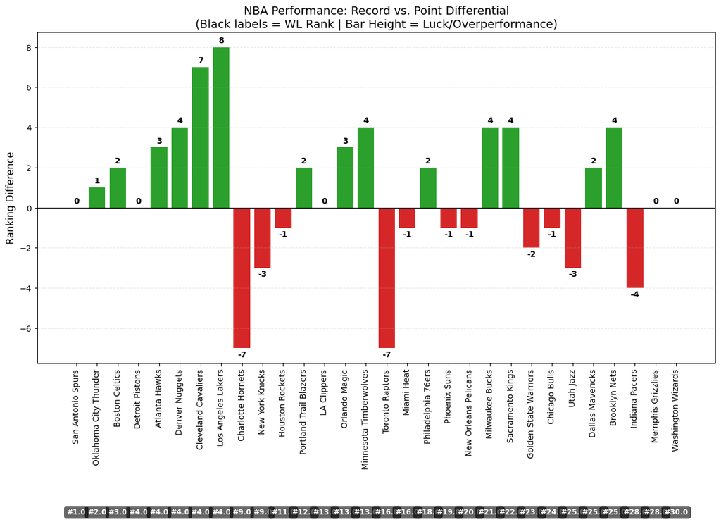

```python
# 1. Calculate the win rate and average point differential
team_stats = nba_last_30_games.groupby('TEAM_NAME').agg({
    'WL': lambda x: (x == 'W').mean(),
    'PLUS_MINUS': 'mean'
}).reset_index()

# 2. Assign rankings (1 = highest/best)
team_stats['WL_RANK'] = team_stats['WL'].rank(ascending=False, method='min')
team_stats['PD_RANK'] = team_stats['PLUS_MINUS'].rank(ascending=False, method='min')

# 3. Calculate Difference: (PD Rank - WL Rank)
# If PD Rank is 3rd and WL Rank is 1st: 3 - 1 = +2 (Overperforming)
team_stats['RANK_DIFF'] = team_stats['PD_RANK'] - team_stats['WL_RANK']

# 4. Sort by WL Record, and PD Rank for ties
team_stats = team_stats.sort_values(by=['WL_RANK', 'PD_RANK'])

# 5. Plotting
fig, ax = plt.subplots(figsize=(15, 9))
colors = ['#2ca02c' if x >= 0 else '#d62728' for x in team_stats['RANK_DIFF']]
bars = ax.bar(team_stats['TEAM_NAME'], team_stats['RANK_DIFF'], color=colors)

# 6. Difference Labels (on the bars)
ax.bar_label(bars, padding=3, fontweight='bold')

# 7. WL Rank Labels (Placed lower down)
# We calculate a 'bottom' value based on the lowest bar to ensure it's below everything
y_offset = team_stats['RANK_DIFF'].min() - 8

for i, row in enumerate(team_stats.itertuples()):
    ax.text(i, y_offset, f"#{row.WL_RANK}",
            ha='center', va='top', fontsize=9,
            fontweight='bold', color='white',
            bbox=dict(facecolor='black', alpha=0.6, boxstyle='round,pad=0.3'))

# Styling
plt.xticks(rotation=90, fontsize=10)
plt.axhline(0, color='black', linewidth=1)
plt.title('NBA Performance: Record vs. Point Differential\n(Black labels = WL Rank | Bar Height = Luck/Overperformance)', fontsize=14)
plt.ylabel('Ranking Difference', fontsize=12)

# Adjusting margins to make room for the new lower labels
plt.subplots_adjust(bottom=0.25)
plt.grid(axis='y', linestyle='--', alpha=0.3)

plt.show()
```